# Script 3: Randomization & Non-Compliance

Script 3 Spring 2026

# Recap

## Selection bias

In the lecture we discussed selection bias, which is the difference in the potential untreated outcomes between those who were treated and those who were not treated. Stated formally:

$$E[Y_{1i} | D_i = 1] - E[Y_{0i} | D_i =
0] = \underbrace{E[Y_{1i} - Y_{0i} | D = 1]}_{ATT} +
\underbrace{E[Y_{0i} | D_i = 1] - E[Y_{0i} | D_i = 0]}_\text{Selection
bias}$$
Using experiments, we can get rid of selection bias as under randomisation units across treatment arms are - in expectation - similar on all (un)observed traits and only differ in terms of treatment assignment $D_I$.

Given that, in expectation potential outcomes are orthogonal (independent) to treatment assignment: $E[Y_{1i} | D_i = 1] = E[Y_{1i}]$ and also $E[Y_{0i} | D_i = 0] = E[Y_{0i}]$

That is, pre-treatment differences in potential outcomes are, on expectation, equal between units assigned to the treatment and the control group. Stated formally:
$$E[Y_{0i} |
D_i = 1] = E[Y_{0i} | D_i = 0]$$
Using both of these assumption, the ATT is equivalent to the ATE. Stated formally:

$$ATE = E[Y_{1i} | D_i = 1] - E[Y_{0i} |
D_i = 0] = \underbrace{E[Y_{1i} - Y_{0i} | D = 1]}_{ATT} +
\underbrace{E[Y_{0i} | D_i = 1] - E[Y_{0i} | D_i =
0]}_\text{0}$$

## Randomisation

- We also discussed ways that we randomly allocate units to either treatment or control:
  - Simple random assignment: a procedure such as a die roll or coin toss that gives each subject identical probability of being assigned to treatment.
  - Complete random assignment: where **m** of N units are assigned to the treatment.
  - Stratified or block randomisation: We conduct complete randomisation within selected groups or within blocks, respectively. Blocks should be determined by a pre-treatment covariate that predicts outcomes.

## One-sided compliance

Oftentimes, we assign units to the treatment group, but they are not eventually treated. Usually, the raeason for not taking the treatment is correlated with the outcome. Thus, we need to figure out how to estimate the treatment effect taking into account that we may have either one-sided or two-sided non compliance.

- Naive solution: Exclude those not treated, and calculate the different-in-means using only treated units. However, if we do this **randomisation is broken**.
- *Intention to treat (ITT)*: Difference in outcomes between units assigned to the treatment group versus those in the control group without taking into account compliance rates.

$$ITT = E[Y_{1i}] - E[Y_{0i}]$$

- Estimate the *Complier Average Causal Effect (CACE)*, which is the treatment effect amongst compliers.

$$CACE = \frac{ITT}{E[D_{1i}]}$$
where $E[D_{1i}]$ is the treatment compliance rate (i.e., the treatment compliance rate in the treated group minus the non-compliance rate in the control group).

**Before starting this seminar**

1. Create a folder called “lab3”
2. Download the data (you can use this button or the one at the top, or read csv files directly from github):
3. Open an R script (or Markdown file) and save it in our “lab3” folder.
4. Set your working directory using the setwd() function or by clicking on “More“. For example *setwd(“~/Desktop/Causal Inference/2026/Script3”)*
5. Let’s install an load packages that we will be using in this lab. Note that you will have to install a package the first time you use it (`install.package("")`). Then, everytime you open R again, you will need to load the package using the `library` command.

```r
# Note: you need to install each package once
library(jtools) # generate plots with regression coefficients
library(stargazer) # generate formated regression tables
library(modelsummary)  # generate formatted regression tables
library(texreg) # generate formatted regression tables
library(nnet)  # If you want to use glm() to check for balance
library(haven) # upload .dta files into a R environment
library(tidyverse) # to conduct some tidy operations
library(ggplot2) # to generate plots
library(AER) # to run IV regressions
library(formatR) # using tidy
library(ggstance) # even more plots
```

# Seminar Overview

In this **seminar**, we will cover the following topics:

1. Use`lm()` function to retrieve the ATE.
2. Report regression estimates `stargazer package` and coefficients using the `coefplot package`
3. Evaluate differential effects conducting an interaction.
4. Conduct a simple and stratified random assignment.
5. Calculate the proportion of **never takers**, **always takers**, and **defiers**.
6. Retrieve the `Intention-to-treat` using the `mean()`, `lm()`, `ivreg()` functions.
7. Estimate the Compliers Average Causal Effect using the `mean()` function and Two-Stage-Least Squares using the `ivreg()` function.

## Experiments

You already know various types of experiments, such as survey experiments, lab experiments, field experiments.

How do natural experiments fit in?

- IR: Rotating Presidency of the Council of the EU (Carnegie/Marinov 2017)
- CP: Population size & electoral system (Eggers 2015)
- many others…
- IR/CP: Election Observation (Hyde 2007)

## Election Monitoring

Today We will be working with data from Susan Hyde’s work on the [**Observer Effect in International Politics**](https://heinonline.org/HOL/Page?handle=hein.journals/wpot60&div=6&id=&page=&collection=journals), where she analyses a natural experiment in Armenia.

Hyde sought to identify a relatively broad but surprisingly understudied research question: *Do international monitoring missions have an effect on electoral outcomes?*

Satisfactorily answering this question is harder than it seems. As Hyde reasons, cross-sectional comparisons (i.e. comparing mutliple countries) as well as cross-temporal comparisons cannot provide robust evidence of an observer effcect. Endogeneity will inevitably play a role in such analyses. She finds a solution to this problem by observing the *microlevel*. Instead of looking at outcomes at national level, she wants to find out what effect observers have on election-day fraud. To do so, she analyses individual polling stations.

Hyde selects the 2003 presidential elections in Armenia for her analysis, for three particular reasons:

- There clearly was some fraud on election day (remember: we need variation in the outcome). The election has been described as *‘one of the dirtiest even Armenians can remember’* (p.47).
- Disaggregated data were available (note that this was by no means a given in 2003). [Do you think reporting election results online becoming a standard in virtually all countries has impacted fraud? Why (not)?]
- Assignment was ‘as-if’ random by the OSCE. Hyde mentions some possible probems associated with the randomness of observer assignment but argues that these were mitigated by the OSCE’s approach.

Given the assumption of random assignment, Hyde conceives of the assignment of observers as natural experiment. The outcome of interest is the incumbent’s vote share as the incumbent candidate is likely to use the administrative apparatus to commit fraud. The assumption of randomness entails that the expected outcome of both observed and unobserved polling stations would be the same if no observer mission took place.

Hyde concludes that the observer effect is signifcant. That is, the presence of international observers on election day prevents fraud in the observed polling stations. She finds that between observed and unobserved polling stations there was a **5.9%-point** difference in incumbent vote share in the first round and a **2%-point** difference in the second round. Note that these are simple differences in means.

A description of the variables is listed below:

| Variable | Description |
| --- | --- |
| `mon_voting` | Binary variable equal to 1 if observers were present in polling station in Round 1 |
| `kocharian` | Vote share of the incumbent (Robert Kocharian) in Round 1 |
| `mon_voting_R2` | Binary variable equal to 1 if observers were present in polling station in Round 2 |
| `KocharianR2` | Vote share of the incumbent (Robert Kocharian) in Round 2 |
| `osce_assignment` | Binary variable equal to 1 if OSCE was assigned to observe the polling station (Note: these are fictional data) |
| `pollingstation` | Name and number of polling station |
| `subregion` | Armenian region the polling station is located |
| `urban` | Binary variable equal to 1 if the polling station is located in an urban area |
| `voterspersqkm` | Continuous variable indicating population density |

Now let’s load the data. There are two ways to do this:

You can load the brands dataset from your laptop using the `read_dta()` function. Remember to load the `haven` package. If you stored your data in the same directory that set your working directory, you only need to write the name of the dataset, plus the extension (.dta).

```r
# setwd("C:/Desktop/Causal Inference/2026/Script3")
#
# library(haven)
# hyde2007 <- read_dta("hyde2007.dta") # loading your data from your laptop
```

Or you can load the data from the course website using the `read.dta()` function. Write the following url: https://github.com/bayreuth-politics/CI26/blob/main/docs/data/hyde2007.dta?raw=true inside the `read.dta()` function

```r
hyde2007=read_dta("https://github.com/bayreuth-politics/CI26/blob/main/docs/data/hyde2007.dta?raw=true")
# updating the file from the course website.
```

Let’s start this lab by inspecting the data. You can use either `head()` or `glimpse()` function. You may want to select the variables that you want to inspect and then combine these variables using the `cbind()` function. The syntax would be the following `head(cbind(dataframe$variable1, dataframe$variable2...dataframe$variable3))`.

**Exercise 1: Inspect the following variable: pollingstation, urban,voterspersqkm,kocharian,mon_voting,mon_voting_R2, KocharianR2, osce_assignment.**

**Reveal Answer**

```r
head(cbind(hyde2007$pollingstation, hyde2007$urban, hyde2007$voterspersqkm, hyde2007$kocharian, hyde2007$mon_voting, hyde2007$mon_voting_R2, hyde2007$KocharianR2, hyde2007$osce_assignment))
```

```
     [,1]                                [,2] [,3]
[1,] "\xa0 1671. Agarak, Club"              "0"  "27.9790992736816"
[2,] "\xa0 1620. Arevis, School"            "0"  "77.8955993652344"
[3,] "\xa0 0691. Urtsalanj, School"         "0"  "88.6297988891602"
[4,] "\xa0 0959. Norabak, secondary School" "0"  "41.4747009277344"
[5,] "\xa0 1188. Shamlugh, Cultural House"  "0"  "63.1679000854492"
[6,] "\xa0 0678. Erasghavan, School"        "0"  "88.6297988891602"
     [,4]                [,5] [,6] [,7]                [,8]
[1,] "1"                 "1"  "0"  "0.977800011634827" "1"
[2,] "0.942900002002716" "0"  "0"  "1"                 "1"
[3,] "0.529999971389771" "1"  "0"  "0.676199972629547" "1"
[4,] "0.693899989128113" "1"  "0"  "0.868399977684021" "1"
[5,] "0.506200015544891" "0"  "0"  "0.874300003051758" "1"
[6,] "0.685899972915649" "1"  "0"  "0.776600062847137" "1"
```

Now let’s check how many observations were observed or *treated*. The treatment variable is `mon_voting`. We can use the `table()` function to get the number of polling stations were monitored. The syntax is the following: `table(df$variable)`:

**Exercise 2: How many polling stations were observed in the first round?**

**Reveal Answer**

```r
table(hyde2007$mon_voting)
```

```
   0    1
1016  748
```

We can see that out of the `1764` polling stations,`748` were monitored.

Now that we have inspected the data, let’s calculate the difference in means of Kocharian’s vote share (`kocharian`) between monitored and unmonitored polling stations. Let’s check if we get the same numbers reported by Hyde.

**Exercise 3: Calculate the difference in means using the `mean()` function. Remember to subset the data by setting a logical condition within the squared brackets `[df$variable == TRUE, ]`. The data frame will subset the data selecting the rows that meet the logical condition. Here is the syntax to calculate the difference in means `mean(df$outcome[df$treatment == 1])`. Recall to remove missing values for the calculation `(na.rm=T)`.**

**Reveal Answer**

```r
diffmeans  <- mean(hyde2007$kocharian[hyde2007$mon_voting==1]) - mean(hyde2007$kocharian[hyde2007$mon_voting==0], na.rm=T)
diffmeans
```

```
[1] -0.05867601
```

We got the same estimates as Hyde. This difference in means can be interpreted as an average difference in vote share of `5.9` percentage points in support of Kocharian in polling station that were monitored versus those not monitored.

We can also get the difference in means using the `t.test()` We can do this by retrieving the means of each groups from a two sample t-test output.

**Exercise 4: Perform a two sample t-test using the `t.test()` function. The syntax is as follows: `t.test(df$outcome ~ df$treatment)`. Use the assignment operator `<-` to store the output of the t-test into an object, which allows us to retrieve the means of each group from this test.**

**Reveal Answer**

```r
t.test1 <-t.test(hyde2007$kocharian ~ hyde2007$mon_voting)
t.test1
```

```
    Welch Two Sample t-test

data:  hyde2007$kocharian by hyde2007$mon_voting
t = 5.9911, df = 1675.8, p-value = 2.546e-09
alternative hypothesis: true difference in means between group 0 and group 1 is not equal to 0
95 percent confidence interval:
 0.03946639 0.07788563
sample estimates:
mean in group 0 mean in group 1
      0.5419031       0.4832271
```

To calculate the difference in means we need to retrieve the means of both monitored and not monitored groups from the t-test output. To do this, we need to know the names that the `t.test()` function gives to each parameter that it generates. To do that, we can use the `names()` function. The syntax is as follows: `names(object)` .

```r
names(t.test1) # we can see the names of each of the parameters generated by the t.test function.
```

```
 [1] "statistic"   "parameter"   "p.value"     "conf.int"    "estimate"
 [6] "null.value"  "stderr"      "alternative" "method"      "data.name"
```

We see that the `t.test()` function stores the means and calls them *“estimate”* .

We can retrieve the means from the object where we stored the t-test output by including a dollar sign $, plus estimate. We can also use the `round()` function to round off values to a specific number of decimal values. The syntax of the `round()` function is the following `round(x, digits = 2)` where x is the object (variable). The second argument is the number of decimals that you want to report.

**Exercise 5: Obtain the mean vote share for Kocharian in observed and unobserved polling stations. Use the output of the t.test using the following syntax: `t.test.object$estimate`.Then, retrieve the means of the monitored and not monitored polling stations using the following syntax: `t.test.object\$estimate[2]` (for monitored polling stations) and `t.test.object\$estimate[1]` (for unmonitored polling stations). Finally, subtract these two objects and round their difference, reporting 3 decimals. Use the `round()` function to do this.**

**Reveal Answer**

```r
t.test1$estimate
```

```
mean in group 0 mean in group 1
      0.5419031       0.4832271
```

```r
diff_means_ttest <- round(t.test1$estimate[2] - t.test1$estimate[1], 3) # w
diff_means_ttest
```

```
mean in group 1
         -0.059
```

We see that we obtained the same result as before: `-0.059`. It is important to understand that you can retrieve and operate with values from R objects. As you can see, however, this is not the most straightforward way to retrieve the difference in means here.

We know that we use regressions to analyse data from randomised experiments. It turns out that regressing an outcome variable on a treatment variable yields a slope coefficient identical to the difference in means between *two* groups. In addition, the resulting intercept corresponds to the average outcome among the control (untreated) units. Bear in mind that the difference in means estimator is equal to the coefficient of the treatment variable only when the treatment variable is binary.

**Exercise 6: Regress the outcome variable `kocharian` on the treatment variable, `mon_voting`. Interpret the coefficient of the `mon_voting` variable. Is the coefficient identical to the difference in means obtained before? Load the `stargazer` package and report this model in a regression table. The syntax of the stargazer model is the following `stargazer(model, title="Results", align=TRUE, type = "text")` where model is the object where you stored the output of your regression. Add a title to your regression table and call it “Results”. Also set the `align` argument equal to TRUE, so the numeric values in the same column will be aligned at the decimal mark. Finally, set the `type` argument equal to `"text"` to specifies what type of output the command should produce. You can also use `modelsummary()` or `texreg()` to report regression tables, feel free to use these packages as well.**

**Reveal Answer**

```r
library(stargazer)
ols1=lm(kocharian ~ mon_voting, data=hyde2007)
stargazer(ols1, title = "Results", align = TRUE, type = "text")  # using stargazer
```

```
Results
===============================================
                        Dependent variable:
                    ---------------------------
                             kocharian
-----------------------------------------------
mon_voting                   -0.059***
                              (0.010)

Constant                     0.542***
                              (0.006)

-----------------------------------------------
Observations                   1,764
R2                             0.019
Adjusted R2                    0.019
Residual Std. Error      0.206 (df = 1762)
F Statistic          35.022*** (df = 1; 1762)
===============================================
Note:               *p<0.1; **p<0.05; ***p<0.01
```

From the regression we obtained the same value as the one from when we “manually” calculated the difference in means before. The beta coefficient of the `mon_voting` variable means that the vote share for Kocharian decreased by `5.9` percentage points once international observers monitor the election process. We also see that the intercept is equal to `0.542`. This parameter represents the average vote share for Kocharian in those polling stations that were not monitored.

As we did in the last script, we would like to look check that the randomisation was successful. In particular, we would like to look at whether there is balance between urban and rural areas.

**Exercise 7: Create a contingency table using the `tab()` function. Get the number of polling stations that were monitored versus those that were not monitored (variable: `mon_voting`), both for urban and rural areas (variable: `urban`). The syntax is the following: `table(df$variable_1, df$variable_2)`. Are there differences in the number of polling stations monitored between these two areas?**

**Reveal Answer**

```r
table(hyde2007$urban, hyde2007$mon_voting)
```

```
      0   1
  0 500 285
  1 516 463
```

We can see that there are more polling stations were monitored in urban areas `(463)` versus in rural areas `(285)`.

Now, let’s use `prop.test()` to check whether there is imbalance between urban and rural areas. You can do this by storing the previous table in a object, and then insert this object inside the `prop.test()` function.

**Exercise 8: Run the `prop.test()` function. Do you find unbalance in terms of the number of polling stations between urban and rural?**

**Reveal Answer**

```r
prop.test(table(hyde2007$urban, hyde2007$mon_voting))
```

```
    2-sample test for equality of proportions with continuity correction

data:  table(hyde2007$urban, hyde2007$mon_voting)
X-squared = 21.088, df = 1, p-value = 4.388e-06
alternative hypothesis: two.sided
95 percent confidence interval:
 0.06279495 0.15695353
sample estimates:
   prop 1    prop 2
0.6369427 0.5270684
```

From the `prop.test()` function, we find that around 63.6% of the polling stations in the rural area were not monitored, whereas in the urban area only roughly 52% remained unmonitored. We find a statistically significant difference in the proportions of polling stations that were not observed. This is potentially problematic as this results indicate a potential violation of the randomisation assumption.

We can also check for balance by regressing the treatment assignment variable `mon_voting` on the covariate(s) of interest `urban`. Let’s do that in the following exercise.

**Exercise 9: Regress `mon_voting` on `urban`. Again, report the results in a regression table. Change the title to “Randomisation check”.**

**Reveal Answer**

```r
balance_urban=lm(mon_voting ~ urban, data=hyde2007)

stargazer(balance_urban, title = "Randomisation check", align = TRUE, type = "text") # using stargazer
```

```
Randomisation check
===============================================
                        Dependent variable:
                    ---------------------------
                            mon_voting
-----------------------------------------------
urban                        0.110***
                              (0.024)

Constant                     0.363***
                              (0.018)

-----------------------------------------------
Observations                   1,764
R2                             0.012
Adjusted R2                    0.012
Residual Std. Error      0.491 (df = 1762)
F Statistic          21.777*** (df = 1; 1762)
===============================================
Note:               *p<0.1; **p<0.05; ***p<0.01
```

Note that as opposed to the `prop.test` where we got the share of unmonitored stations, the regression gives us the share of monitored stations (the results are equivalent - feel free to do the math!)

What do we conclude? Do we have reason to think this might affect the validity of the results? One key feature of randomised experiments is that they might be able generate unbiased estimates of the average treatment effect even if there is imbalance. We also know that we can use the covariate `urban` to eliminate observed differences between treatment and control groups and reduce variance in outcomes. **However, we should be suspicions that we find such a large difference between the two areas areas.**

Let’s ignore the differences in the number of polling stations monitored between urban and rural areas for now. Let’s look at heterogeneous treatment effects - that is unequal effects of the treatment among groups - and identify whether there is a differential response to international monitoring between urban and rural areas. For that, we could interact the treatment variable `mon_voting` with the `urban` variable. The syntax is the following `lm(Outcome variable = Treatment variable + Covariate + Covariate * Treatment variable)`

**Exercise 10: Run a regression where the dependent variable `kocharian` is regressed on `mon_voting`, the `urban` variable and an interaction between `mon_voting` and `urban`. Interpret the coefficient of the `mon_voting` and the interaction. Do you find evidence of a differential response to being monitored between polling stations in urban versus rural areas? Also, interpret the coefficient on the `urban` variable. Present the results in a regression, but also include the previous model conducted in Exercise 6 (bivariate model), so you can compare both models. The syntax using stargazer is the following stargazer(model1, model2, title = “Models, align =TRUE, type =”text”).**

**Reveal Answer**

```r
ols1_interaction =lm(kocharian ~ mon_voting + urban + mon_voting*urban, data=hyde2007)

stargazer(ols1, ols1_interaction, title = "Models", align = TRUE, type = "text")
```

```
Models
=====================================================================
                                   Dependent variable:
                    -------------------------------------------------
                                        kocharian
                              (1)                      (2)
---------------------------------------------------------------------
mon_voting                 -0.059***                 -0.028*
                            (0.010)                  (0.015)

urban                                                 0.003
                                                     (0.013)

mon_voting:urban                                     -0.050**
                                                     (0.020)

Constant                    0.542***                 0.540***
                            (0.006)                  (0.009)

---------------------------------------------------------------------
Observations                 1,764                    1,764
R2                           0.019                    0.025
Adjusted R2                  0.019                    0.023
Residual Std. Error    0.206 (df = 1762)        0.205 (df = 1760)
F Statistic         35.022*** (df = 1; 1762) 14.863*** (df = 3; 1760)
=====================================================================
Note:                                     *p<0.1; **p<0.05; ***p<0.01
```

Before we proceed, let’s make clear how the interpretation of an interaction term works. What the moel allows us, essentially, is to estimate different effects of the treatment on urban and rural areas. For instance, we can read the group means for unmonitored rural pollings stations (`Constant`); monitored rural stations (`Constant` + `mon_voting`) unmonitored urban stations (`Constant` + `urban`); and monitored urban stations (`Constant` + `mon_voting` + `urban` + `mon_voting:urban`).

Now, we find that when controlling for `urban` the point estimate of the `mon_voting` yields a much smaller treatment effect (roughly half of the former estimate). Now the ATE is `-0.028` but yet statistically significant. The non-zero coefficient on the interaction between `urban` and `mon_voting` means that support to being monitored has a differential effect on vote share for Kocharian between urban vs rural areas. This interaction coefficient (`0.050`) is the average difference in the effect of `mon_voting` between urban and rural areas. This substantively means that the average effect of monitoring on the vote share for Kocharian is about `5%`-point smaller in urban areas than in rural areas. Finally, the coefficient from the `urban` variable indicates the average difference in vote share for Kocharian between urban and rural areas, when there is no monitoring `mon_voting = 0`. Here, we don’t find a significant effect. This is unexpected as urban areas usually show different voting patterns than rural regions do. Given the imbalanced patterns of observation, the monitoring effect is likely to absorb the rural-urban difference. This is a problem.

### Round 2 of monitoring

In this study, the OSCE (Organization for Security and Co-operation in Europe) conducted a second wave of inspections for the second round of the elections. Let’s quickly replicate the same analyses that we did before.

**Exercise 11: Regress the outcome variable `KocharianR2` on the treatment variable `mon_voting_R2`. You can use the `summary()` or `tidy()` function to report your results. Is the treatment effect weaker or stronger in this round?**

**Reveal Answer**

```r
ols2 <- lm(KocharianR2 ~ mon_voting_R2, data=hyde2007)
summary(ols2)
```

```
Call:
lm(formula = KocharianR2 ~ mon_voting_R2, data = hyde2007)

Residuals:
     Min       1Q   Median       3Q      Max
-0.69251 -0.10281 -0.00287  0.11904  0.32733

Coefficients:
               Estimate Std. Error t value Pr(>|t|)
(Intercept)    0.692511   0.004781 144.841   <2e-16 ***
mon_voting_R2 -0.019841   0.008043  -2.467   0.0137 *
---
Signif. codes:  0 '***' 0.001 '**' 0.01 '*' 0.05 '.' 0.1 ' ' 1

Residual standard error: 0.1614 on 1761 degrees of freedom
  (1 observation deleted due to missingness)
Multiple R-squared:  0.003444,  Adjusted R-squared:  0.002878
F-statistic: 6.085 on 1 and 1761 DF,  p-value: 0.01373
```

```r
# tidy format
ITT <- tidy(ols2) %>%
  filter(term == "mon_voting_R2") %>%
  pull(estimate)
ITT
```

```
[1] -0.01984091
```

This looks like a somewhat weaker effect of the observers being present. We find that the average treatment effect is now `-0.02`, which means that there is a drop of `2` percentage points in the vote share for Kocharian in the second round of elections when polling stations were monitored.

**Exercise 12: Again, as we did before, let’s check if there is balance for the `urban` variable in the second round. Regress the treatment assignment variable `mon_voting_R2` on `urban`. Report the results using either `summary()` or the `tidy()` function.**

**Reveal Answer**

```r
ols2_urban=lm(mon_voting_R2 ~ urban, data=hyde2007)
summary(ols2_urban)
```

```
Call:
lm(formula = mon_voting_R2 ~ urban, data = hyde2007)

Residuals:
    Min      1Q  Median      3Q     Max
-0.4147 -0.4147 -0.2764  0.5853  0.7236

Coefficients:
            Estimate Std. Error t value Pr(>|t|)
(Intercept)  0.27643    0.01689  16.365  < 2e-16 ***
urban        0.13828    0.02267   6.099 1.31e-09 ***
---
Signif. codes:  0 '***' 0.001 '**' 0.01 '*' 0.05 '.' 0.1 ' ' 1

Residual standard error: 0.4733 on 1762 degrees of freedom
Multiple R-squared:  0.02067,   Adjusted R-squared:  0.02012
F-statistic: 37.19 on 1 and 1762 DF,  p-value: 1.313e-09
```

We again find imbalance between urban and rural areas. This linear probability model suggests that urban areas are associated with an increase in the probability of being observed by `13%-points` as compared to rural areas.

Given that we are working with a binary treatment variable, we could also use `glm()`. You can try this on your own and interpret the results from this estimation.

Let’s perform the same analysis that we did before for the first round to obtain the ATE for the second round. Include the variable `urban` and also include interaction between `urban` and `mon_voting_R2`.

**Exercise 13: Find the treatment effect using the `lm()` function. Include the `urban` variable as a covariate. Also include the interaction between `mon_voting_R2` with `urban`. Interpret the results for both `mon_voting_R2` an the interaction term. Report your results in a regression table. Use either `stargazer()`, `screenreg()` or `modelsummary()`. Give the following names to your model: “Second round”. Report the results with 3 decimals.**

**Reveal Answer**

```r
ols2_interaction=lm(KocharianR2 ~ mon_voting_R2 + urban + urban*mon_voting_R2, data=hyde2007)

library(texreg)
screenreg(ols2_interaction, digits = 2, custom.model.names = c("Second round"),
          custom.coef.names = c("Intercept", "Monitor", "Urban", "Monitor:Urban"))
```

```
===========================
               Second round
---------------------------
Intercept         0.67 ***
                 (0.01)
Monitor           0.01
                 (0.01)
Urban             0.04 ***
                 (0.01)
Monitor:Urban    -0.06 ***
                 (0.02)
---------------------------
R^2               0.01
Adj. R^2          0.01
Num. obs.      1763
===========================
*** p < 0.001; ** p < 0.01; * p < 0.05
```

We find that the treatment effect for the second round is `0.01` - slightly smaller and no longer statistically significant. However, we do find a differential response to the treatment as the interaction is statistically significant. This coefficient of the interaction can be interpreted as follows: The average effect of monitoring on vote share for Kocharian is about `6%`-points smaller for polling stations in urban areas than in rural areas.

Let’s create a single regression table with some of the regressions that we have estimated so far. You can use the `stargazer()` function, but feel free to use `texreg()` or `modelsummary()`.

**Exercise 14: Include the regression models into single regression table. Change the title to: “Regression results - All rounds”. Call the bivariate models “Baseline” and models with interaction “Interaction”. To do this, include the following argument: `column.labels = c("Name 2", "Name3")`. Also, set labels for the dependent variables that you analysed in the first round and the second round. You can do this by adding the following argument `dep.var.labels = c("First Round", "Second Round")`. Finally, let’s change the labels of the variables by including the `covariate.labels = c("label variable 1", "label variable 2")`**

**Reveal Answer**

```r
stargazer(ols1, ols1_interaction, ols2, ols2_interaction,
          title = "Regression results - All rounds",
          column.labels = c("Baseline", "Interaction", "Baseline", "Interaction"),
          dep.var.labels = c("First round", "Second round"),
          covariate.labels = c("Monitored", "Urban", "Monitor:Urban", "Monitor round 2:Urban","Monitor round 2" ),
          align = TRUE,
          type = "text")
```

```
Regression results - All rounds
======================================================================================================================
                                                            Dependent variable:
                      ------------------------------------------------------------------------------------------------
                                         First round                                     Second round
                              Baseline               Interaction               Baseline              Interaction
                                (1)                      (2)                     (3)                     (4)
----------------------------------------------------------------------------------------------------------------------
Monitored                    -0.059***                 -0.028*
                              (0.010)                  (0.015)

Urban                                                   0.003                                         0.038***
                                                       (0.013)                                         (0.010)

Monitor:Urban                                          -0.050**
                                                       (0.020)

Monitor round 2:Urban                                                                                 -0.060***
                                                                                                       (0.017)

Monitor round 2                                                                -0.020**                 0.013
                                                                               (0.008)                 (0.013)

Constant                      0.542***                 0.540***                0.693***               0.673***
                              (0.006)                  (0.009)                 (0.005)                 (0.007)

----------------------------------------------------------------------------------------------------------------------
Observations                   1,764                    1,764                   1,763                   1,763
R2                             0.019                    0.025                   0.003                   0.014
Adjusted R2                    0.019                    0.023                   0.003                   0.012
Residual Std. Error      0.206 (df = 1762)        0.205 (df = 1760)       0.161 (df = 1761)       0.161 (df = 1759)
F Statistic           35.022*** (df = 1; 1762) 14.863*** (df = 3; 1760) 6.085** (df = 1; 1761) 8.210*** (df = 3; 1759)
======================================================================================================================
Note:                                                                                      *p<0.1; **p<0.05; ***p<0.01
```

From the previous analysis we might wonder to what extend the rounds are independent of each other. Hyde states the following in this regard:

- Hyde concludes that her *“results suggest that if first-round monitoring took place then second-round monitoring had only a marginal additional deterrent effect.”* (p.56). She therefore claims that first-round observation has a persistent effect.

Let’s see whether monitoring in the two rounds was independent. First, we check the number of polling stations observed per round.

```r
sum(with(hyde2007, mon_voting==0 & mon_voting_R2==0))
```

```
[1] 756
```

```r
sum(with(hyde2007, mon_voting==1 & mon_voting_R2==0))
```

```
[1] 385
```

```r
sum(with(hyde2007, mon_voting==0 & mon_voting_R2==1))
```

```
[1] 260
```

```r
sum(with(hyde2007, mon_voting==1 & mon_voting_R2==1))
```

```
[1] 363
```

Well, in Round 2 more stations were observed that had been monitored in Round 1 than those that had not been monitored. Let’s confirm significance. For that we can conduct a two sample test of proportions.

```r
prop.test(table(hyde2007$mon_voting_R2, hyde2007$mon_voting))
```

```
    2-sample test for equality of proportions with continuity correction

data:  table(hyde2007$mon_voting_R2, hyde2007$mon_voting)
X-squared = 98.233, df = 1, p-value < 2.2e-16
alternative hypothesis: two.sided
95 percent confidence interval:
 0.1965443 0.2939381
sample estimates:
   prop 1    prop 2
0.6625767 0.4173355
```

What do we conclude?

- The evidence suggest that monitoring in round 2 was not in fact random - it was conditional on the treatment (and thus results?) of the first round.
- If we apply experimental standards (which is what we should do), we conclude that Round 2 monitoring was not independent from Round 1 monitoring. Hence, we cannot simply conceive of round 2 monitoring as randomised treatment assignment.

Finally, let’s plot all coefficients from the regressions conducted in **Exercises 6, 10, 11 and 13** together. There are multiple packages to plot regression estimates. One of them is `jtools`. We can use the `plot_summs` function to create regression coefficient plots with `ggplot2`.

The first step is to store all regressions in separate objects. You should have 4 models in 4 separate objects: two bivariate models and two models with interactions. We can store all of the objects in a list. A list in R is object that can contain multiple objects. This facilitates the syntax that we need to use whenever we seek to generate a plot with multiple models.

```r
# bivariable model first round
ols1
```

```
Call:
lm(formula = kocharian ~ mon_voting, data = hyde2007)

Coefficients:
(Intercept)   mon_voting
    0.54190     -0.05868
```

```r
# model with interaction first round
ols1_interaction
```

```
Call:
lm(formula = kocharian ~ mon_voting + urban + mon_voting * urban,
    data = hyde2007)

Coefficients:
     (Intercept)        mon_voting             urban  mon_voting:urban
        0.540319         -0.027811          0.003119         -0.050424
```

```r
# bivariate model second round
ols2
```

```
Call:
lm(formula = KocharianR2 ~ mon_voting_R2, data = hyde2007)

Coefficients:
  (Intercept)  mon_voting_R2
      0.69251       -0.01984
```

```r
# model with interaction second round
ols2_interaction
```

```
Call:
lm(formula = KocharianR2 ~ mon_voting_R2 + urban + urban * mon_voting_R2,
    data = hyde2007)

Coefficients:
        (Intercept)        mon_voting_R2                urban
            0.67343              0.01324              0.03802
mon_voting_R2:urban
           -0.05951
```

```r
models <- list(ols1,
               ols1_interaction,
               ols2,
               ols2_interaction)
```

The second step is to include this list the `plot_summs()` function. Add the following argument inside of the `plot_summs()` function: `scale = TRUE`. This generates a version of the plot with standardised coefficients. Also, include the following argument: `robust = TRUE`. When setting `robust = TRUE`, the plot will generate confidence intervals using robust standard errors.

**Exercise 15: Generate a plot with the coefficients of all four models using `plot_summs() function**

**Reveal Answer**

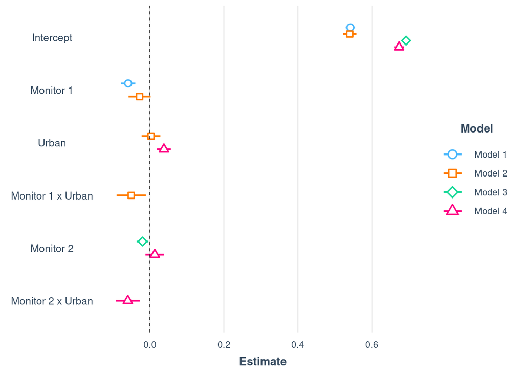

```r
coefficients <- c("Intercept" = "(Intercept)","Monitor 1" = "mon_voting", "Urban" = "urban", "Monitor 1 x Urban" = "mon_voting:urban", "Monitor 2" = "mon_voting_R2", "Monitor 2 x Urban" = "mon_voting_R2:urban")

plot_summs(models, coefs = coefficients, scale = TRUE, robust = TRUE)
```

## Randomisation

We already found meaningful imbalance, both within each of the rounds and between them. Polling stations in urban areas were much more likely to be observed than rural ones in the first round of the elections. We know that we can’t control for all possible confounders, but is *this* imbalance a problem for the validity of Hyde’s research design? Why?

Let’s check if we get a similar result for population density to make sure the imbalance is not simply caused by the way the `urban` variable was constructed.

**Exercise 16: Find out whether randomization worked regarding population density (`voterspersqkm`).**

**Reveal Answer**

```r
#Population Density
ks.test(hyde2007$voterspersqkm[hyde2007$mon_voting==0],
        hyde2007$voterspersqkm[hyde2007$mon_voting==1])
```

```
    Two-sample Kolmogorov-Smirnov test

data:  hyde2007$voterspersqkm[hyde2007$mon_voting == 0] and hyde2007$voterspersqkm[hyde2007$mon_voting == 1]
D = 0.26816, p-value < 2.2e-16
alternative hypothesis: two-sided
```

```r
# Lookin at means only
t.test(hyde2007$voterspersqkm~hyde2007$mon_voting, data=hyde2007)
```

```
    Welch Two Sample t-test

data:  hyde2007$voterspersqkm by hyde2007$mon_voting
t = -12.156, df = 1221.9, p-value < 2.2e-16
alternative hypothesis: true difference in means between group 0 and group 1 is not equal to 0
95 percent confidence interval:
 -914.4994 -660.3231
sample estimates:
mean in group 0 mean in group 1
       443.6667       1231.0779
```

Given that population density is a continuous variable, we can use a `t-test` to look at differences in means and a `ks.test` for meaningful differences in the distribution between observed and unobserved polling stations.

All these stats show that there is an imbalance between observed and unobserved polling stations. That is, the treatment (monitoring) was not randomly received with regard to population density and urbanisation. This is a very concerning problem as we know from various studies that urban and rural demographics are different, particularly when it comes to political predisposition. Recall what this means in terms of potential outcomes: the problem here is that what we might think to be the treatment effect may actually just be selection bias.

**Exercise 17: Randomise the assignment to treatment. Use (i) complete random assignment and (ii) stratified randomisation.**

Since randomisation was not, in fact, successful in the natural setting, let’s ourselves create a variable for random treatment assignment. We assume that 50% of all polling stations can be observed.

*Note: There are two ways to do this:*  
- *You can use either the `rbinom` function to randomly assign a dummy variable, which follows the following syntax: ``rbinom(n, size, prob)`, where `n` is the number of observations, `size` is the number of trials per observation and `prob` the probability of success (or a positive result)*  
- *Or you use the `simple_ra` function from the `randomizr`package. You only need to specify arguments for `n` and `probability`.*

**Reveal Answer**

```r
hyde2007$random_assignment <- rbinom(n=1764, size=1, prob=0.5)

table(hyde2007$random_assignment)
```

```
  0   1
856 908
```

```r
# or
library(randomizr)
hyde2007$random_assignment <- simple_ra(N = 1764, prob = 0.5)

table(hyde2007$random_assignment)
```

```
  0   1
869 895
```

**[Optional: see more ways to randomise using the `randomizr` package]**

The `randomizr` package includes various options for randomisation. You can easily achieve block randomisation or even randomise the assignment of various treatments. These are just a few examples:

```r
hyde2007$multiarm_assignment <- complete_ra(N = 1764, prob_each = c(0.2, 0.3, 0.5), conditions = c("Treatment 1", "Treatment 2", "Control")) ## multiple treatments

table(hyde2007$multiarm_assignment)
```

```
Treatment 1 Treatment 2     Control
        353         529         882
```

```r
hyde2007$block_assignment <- block_ra(blocks = hyde2007$urban,
prob_each = c(.1, .1, .8))

table(hyde2007$block_assignment)
```

```
  T1   T2   T3
 177  176 1411
```

Assume now that the OSCE has been made aware of this problem regarding rural areas. For some reason, urban polling stations are more likely to be monitored than rural ones. For their next assignment, they want to make sure rural polling stations are just as likely to be observed as urban ones. To have enough resources to ensure that every single polling station that is assigned to be observers will in fact be observed, they reduce the overall number of polling stations to 30% but use stratified randomisation.  
*Note: The easiest way to do this is using the `strata_rs` command from the `randomizr` package. You just need to specify the `strata` and `prob` arguments.*

**Reveal Answer**

```r
#install.packages("randomizr")
library(randomizr)
hyde2007$stratified <- strata_rs(strata = hyde2007$urban, prob = .3)
```

This should be much better now. Nonetheless, we should make sure randomisation was successful - checking both random assignment and stratified randomisation - to avoid working with flawed data.

```r
# Complete Random Assignment Balance Checks
t.test(hyde2007$voterspersqkm~hyde2007$random_assignment, data=hyde2007)
```

```
    Welch Two Sample t-test

data:  hyde2007$voterspersqkm by hyde2007$random_assignment
t = -1.9843, df = 1760, p-value = 0.04738
alternative hypothesis: true difference in means between group 0 and group 1 is not equal to 0
95 percent confidence interval:
 -248.828608   -1.450141
sample estimates:
mean in group 0 mean in group 1
       714.0657        839.2051
```

```r
prop.test(table(hyde2007$urban, hyde2007$random_assignment))
```

```
    2-sample test for equality of proportions with continuity correction

data:  table(hyde2007$urban, hyde2007$random_assignment)
X-squared = 0.16314, df = 1, p-value = 0.6863
alternative hypothesis: two.sided
95 percent confidence interval:
 -0.05891085  0.03726651
sample estimates:
   prop 1    prop 2
0.4866242 0.4974464
```

```r
# Stratified Randomisation Balance Checks
t.test(hyde2007$voterspersqkm~hyde2007$stratified, data=hyde2007)
```

```
    Welch Two Sample t-test

data:  hyde2007$voterspersqkm by hyde2007$stratified
t = -0.81037, df = 972.68, p-value = 0.4179
alternative hypothesis: true difference in means between group 0 and group 1 is not equal to 0
95 percent confidence interval:
 -193.41501   80.35984
sample estimates:
mean in group 0 mean in group 1
       760.6058        817.1333
```

```r
prop.test(table(hyde2007$urban, hyde2007$stratified))
```

```
    2-sample test for equality of proportions with continuity correction

data:  table(hyde2007$urban, hyde2007$stratified)
X-squared = 1.0575e-29, df = 1, p-value = 1
alternative hypothesis: two.sided
95 percent confidence interval:
 -0.04302202  0.04490877
sample estimates:
   prop 1    prop 2
0.7006369 0.6996936
```

```r
aggregate(hyde2007[, c("mon_voting", "random_assignment", "stratified")], list(hyde2007$subregion), mean)
```

```
            Group.1 mon_voting random_assignment stratified
1           Abovyan  0.4814815         0.5555556  0.2962963
2          Ajapnyak  0.5897436         0.5128205  0.3846154
3          Alaverdi  0.3200000         0.5200000  0.3800000
4          Anrashat  0.7142857         0.3333333  0.2857143
5           Arabkir  0.6818182         0.5454545  0.2727273
6            Ararat  0.6666667         0.3666667  0.2000000
7           Armavir  0.3600000         0.4000000  0.3200000
8         Arshaluys  0.2812500         0.5000000  0.3750000
9             Artik  0.4000000         0.5000000  0.3250000
10         Ashtarak  0.2812500         0.4531250  0.3906250
11             Avan  0.5238095         0.3809524  0.2857143
12           Ayntap  0.5333333         0.4000000  0.2666667
13             Berd  0.4186047         0.6046512  0.3023256
14      Byureghaven  0.3611111         0.5833333  0.3333333
```

[output cut: 26 more lines]

It looks like the problem with first round monitoring is not merely a concentration in urban areas, but an overproportionate presence of monitors in the capital, Yerevan!

`Arabkir, Erebuni, Kentron, Malatia-Sebastia, Nor-Nork, Shengavit` are all districts of Yerevan and vastly overrepresented. The table also shows that this problem would not have appeared if observers had been randomly assigned. This is a good example that shows just how important contextual knowledge is for natural experiments!

Make sure you will be using the `osce_assignment` variable for the next parts of the lab. It provides a fictional example of potential assignment by the OSCE, allowing us to work with the same data.

## Non-Compliance

One of the reasons for the imbalance between rural and urban polling station could be that observers did not observe their assigned polling stations. In that case, one-sided **non-compliance** would be a problem. Polling stations that were supposed to be monitored were, in fact, not monitored on election day. Let’s quickly have a look at the compliance status and the broad picture.

In experiments with one-sided non-compliance compliance like here, units or subjects can be divided into two groups: *Compliers* and *Never takers* . However, in the case of two-sided non-compliance there are subjects that be divided into further groups adding the so-called *Always takers* . These are subjects/units that regardless of their treatment assignment always end up taking the treatment.

Recall that - as compliance types cannot directly be observed - in order to identify the compliance type of units we need further assumptions, particularly **random treatment assignment**.

**Tricky Exercise 18: Generate again a contingency table using the `osce_assignment` and the `mon_voting_R2` variables. Calculate the proportion of *Always takers*.**

**Reveal Answer**

```r
#Let's remember the compliance status [1] 883 [2]258 [3] 0 [4]623
tab.1 <- table(hyde2007$osce_assignment, hyde2007$mon_voting_R2, dnn=c("OSCE Assignment", "Mon Voting 2"))
tab.1
```

```
               Mon Voting 2
OSCE Assignment   0   1
              0 883   0
              1 258 623
```

```r
#Always-Takers
# Under one-sided non-compliance (full compliance in control group) there are no Always takers, so this should be zero
# 0 / (883 + 0) = 0
at <- tab.1[3]/(tab.1[1] + tab.1[3])
at
```

```
[1] 0
```

As pointed out before, there are no *Always takers* in experiments with one-sided compliance like here. If there were *Always takers* , we would expect some of polling stations assigned to control (row = 0) to be monitored (column = 1).

We also have the so-called *Never takers* . These are units that never take the treatment regardless of whether they are assigned to the treatment group or control group.

**Exercise 19: Calculate the proportion of *Never takers* in the study. Use the same contingency table as before. *Hint:* Look at the number of units within those assigned to treatment, and in particular the number of polling stations that were not monitored.**

**Reveal Answer**

```r
tab.1
```

```
               Mon Voting 2
OSCE Assignment   0   1
              0 883   0
              1 258 623
```

```r
#Never Takers
# 258/(258 + 623) = 0.29
# This means that from those polling stations that were assigned to treatment, 29% will not be monitored
nt <- tab.1[2]/(tab.1[2] + tab.1[4])
nt
```

```
[1] 0.292849
```

We can calculate the proportion of *Never takers* by looking the units within the treatment group. The number of *Never takers* are those polling stations assigned to treatment, but not ending up taking the treatment. This is equal to `258`. Then, the proportion is equal to `258` divided by the total number of polling stations assigned to the treatment `258 + 623 = 881`. We cannot directly identify the *Never takers* in the control group, as we cannot disentangle whether units are not taking treatment because they are *Compliers* or because in fact they are *Never takers* . However, if randomisation was indeed successful, we would expect the share of *Never takers* in the control group to be about 29% as well.

Finally, we have the so-called *Compliers* . These are units that follow whatever their assignment is (if assigned to treatment, they do take the treatment; if assigned to control, they don’t). For example, if a polling station was assigned to be monitored, it ends up being monitored. Conversely, if a polling station was assigned to not be monitored, it would end up not being monitored.

**Exercise 20: Calculate the proportion of *Compliers* in the study. Use the same contingency table as before. *Hint:* Look again at the units in the treatment group. In particular the number of polling stations that were monitored.**

**Reveal Answer**

```r
#Compliers (No Defiers By Assumption)
1 - at - nt
```

```
[1] 0.707151
```

So we have `623` units assigned to the treatment and ended up being monitored. Thus, the number of compliers is equal to `623/(258+623) = 0.70`. But we can also obtain the proportion of *Compliers* by subtracting the proportion of *Never takers* and *Always takers* from 1.

A key assumption for identification is that we rule out the existence of the alleged *Defiers*. These units do the opposite of whatever their assignment is (if assigned to treatment, they don’t take the treatment; if assigned to control, they take the treatment).

## Intent-To-Treatment (ITT) & Complier Average Causal Effect (CACE)

Using the ITT is one possible solution to dealing with non-compliance. Remember that the ITT describes intended assignments, not actual treatment. In doing so, it does not simply discard non-complying units.

Let’s start by calculating the ITT manually, using differences in means. Remember that the ITT describes the difference in the outcome between the units *assigned to treatment* and those which were not. In other words, it is the change in expected outcomes when a unit moves from an assigned control group to an assigned treatment group:

$$ITT = E[Y_1~_i] -
E[Y_0~_i]$$

*Note that you find this parameter also written as `ITT.y`, which highlights its referring to the effect in the outcome, `y`.*

**Exercise 21: Using the information on random assignment (`osce_assignment`), calculate the Intent-to-Treat effect (ITT) in Round 2 of the election.**

**Reveal Answer**

There are two ways to calculate the `ITT.y`. First, the difference in means of the outcome variable between the group of units assigned to treatment, on the one hand, and the units assigned to the control group, on the other hand, is equivalent to the `ITT`.

```r
#ITT or ITT.y
itt.y <- (mean(hyde2007$KocharianR2[hyde2007$osce_assignment==1], na.rm = TRUE) - mean(hyde2007$KocharianR2[hyde2007$osce_assignment==0], na.rm = TRUE))
itt.y
```

```
[1] -0.01544005
```

Second, you can run a bivariate OLS regression. As you learned in the previous script, the coefficient of a bivariate OLS is equivalent to the difference in means if the independent variable is binary.

```r
itt_fit <- lm(KocharianR2 ~ osce_assignment, data= hyde2007)
summary(itt_fit)
```

```
Call:
lm(formula = KocharianR2 ~ osce_assignment, data = hyde2007)

Residuals:
     Min       1Q   Median       3Q      Max
-0.69322 -0.10448 -0.00248  0.11818  0.32222

Coefficients:
                 Estimate Std. Error t value Pr(>|t|)
(Intercept)      0.693215   0.005439 127.456   <2e-16 ***
osce_assignment -0.015440   0.007694  -2.007   0.0449 *
---
Signif. codes:  0 '***' 0.001 '**' 0.01 '*' 0.05 '.' 0.1 ' ' 1

Residual standard error: 0.1615 on 1761 degrees of freedom
  (1 observation deleted due to missingness)
Multiple R-squared:  0.002282,  Adjusted R-squared:  0.001715
F-statistic: 4.027 on 1 and 1761 DF,  p-value: 0.04492
```

The results are the same, the `ITT` is about`-0.015`. The difference in the outcome between polling stations assigned to treatment and those that weren’t amounts to `1.5%-points` in the incumbent’s vote share. Does this go together with the reported results?

If there is no non-compliance and assignment to treatment perfectly predicts receiving the treatment, the `ITT` is equivalent to the `ATE`. In our natural experiment, however, many polling stations that should have been observed were not. Accordingly, the `ITT.y` underestimates any true treatment effect. If we don’t care about treatment effects but are only interested in the change in outcome a certain programme or policy brings about, the ITT can be a quantity of interest.

The ITT thus describes the intent-to-treat effect of assignment to treatment (*z*) on the outcome (*Y*). Be aware that this means the outcomes could be influenced either by the assignment to the treatment (and subsequent self-selection into treatment) or the actual treatment.

Let’s therefore now look at the intent-to-treat effect of assignment to treatment (*z*) on treatment (*d*). This second ITT, sometimes called ``ITT.d`, describes the **compliance rate**, i.e., the proportion of subjects who are treated in the event that they had been assigned to the treatment group, minus the proportion who were treated despite having been assigned to the control group:

$$ITT_D = E[d_i(1)] -
E[d_i(0)]$$

Note that in the case of one-sided no compliance, e.g. the case without always-takers as we are facing here, the `ITT.D` reduces to $E[d_i(1)]$. In our analyses, we assume there were no always-takers, i.e. polling stations that were not supposed to be monitored but were, in fact, monitored.

**Exercise 22: Calculate the Intent-to-Treat effect on treatment (`ITT.d`) in Round 2 of the election.**

Here, again, we have the same two options we used to estimate the `ITT`. Both differences in means and a bivariate OLS will provide the `ITT.d`. In the former case, it is the difference in means of the treatment variable, which is equivalent to the share of treated polling stations per group, between polling stations selected for observation missions, on the one hand, on those that hadn’t been selected, on the other hand. In other words, we calculate the share of monitored polling states over all stations assigned for monitoring and subtract the share of monitored stations in the control group from the former.

**Reveal Answer**

```r
#ITT_D
itt.d <- (mean(hyde2007$mon_voting_R2[hyde2007$osce_assignment==1], na.rm = TRUE) - mean(hyde2007$mon_voting_R2[hyde2007$osce_assignment==0], na.rm = TRUE))
itt.d
```

```
[1] 0.707151
```

Equivalently, on OLS regression treatment on assignment to treatment will provide the same result:

```r
## ITT_D using OLS
itt_d_fit <- lm(mon_voting_R2 ~ osce_assignment, data=hyde2007)
summary(itt_d_fit)
```

```
Call:
lm(formula = mon_voting_R2 ~ osce_assignment, data = hyde2007)

Residuals:
    Min      1Q  Median      3Q     Max
-0.7071  0.0000  0.0000  0.2928  0.2928

Coefficients:
                 Estimate Std. Error t value Pr(>|t|)
(Intercept)     6.344e-16  1.083e-02    0.00        1
osce_assignment 7.072e-01  1.532e-02   46.15   <2e-16 ***
---
Signif. codes:  0 '***' 0.001 '**' 0.01 '*' 0.05 '.' 0.1 ' ' 1

Residual standard error: 0.3218 on 1762 degrees of freedom
Multiple R-squared:  0.5473,    Adjusted R-squared:  0.547
F-statistic:  2130 on 1 and 1762 DF,  p-value: < 2.2e-16
```

The results are the same, the `ITT.d` is about`0.71`. In other terms, only 71% of all polling stations that should have been observed were observed during the second round of the elections.

We (and Hyde), however, do not care very much about the differences in outcomes or the ITT itself. The aim of this natural experiment is finding out if electoral monitoring significantly reduces fraud - we want to identify the treatment effect. As stated above, the `ITT` is not equivalent to the `ATE` due to non-compliance.

In this case, the *complier average causal effect* (`CACE`) can be estimated, which corresponds to the `ATE` among compliers:

$$CACE = \frac{ITT_Y}{ITT_D} =
\underbrace{E[(Y_i(d=1) -
Y_i(d=0))}_\text{ATE}|\underbrace{d_i(1)=1}_\text{Among
Compliers}]$$

Note that the CACE is sometimes referred to as *local average treatment effect* (`LATE`).

**Exercise 23: Calculate the CACE using the `ITT.y` and `ITT.d`**

You can simply divide the `ITT` by the `ITT.D` or use the calculations for both quantities and merge them into a single formula.

**Reveal Answer**

```r
#CACE in one line: ITT_Y divided by ITT_D
(mean(hyde2007$KocharianR2[hyde2007$osce_assignment==1], na.rm = TRUE) - mean(hyde2007$KocharianR2[hyde2007$osce_assignment==0], na.rm = TRUE))/(mean(hyde2007$mon_voting_R2[hyde2007$osce_assignment==1], na.rm = TRUE) - mean(hyde2007$mon_voting_R2[hyde2007$osce_assignment==0], na.rm = TRUE))
```

```
[1] -0.02183417
```

```r
cace <- itt.y/itt.d # This should be the same!
print(cace)
```

```
[1] -0.02183417
```

We can also calculate the significance of the CACE. To do so, we calculate the standard errors of the CACE (this is in fact, an approximation): $SE(CACE) \approx SE(ITT.Y) / ITT.D$

```r
se_cace <- summary(itt_fit)$coefficients[4]/itt_d_fit$coefficients
print(se_cace)
```

```
    (Intercept) osce_assignment
   1.212757e+13    1.088013e-02
```

Finally, you can then calculate the p-value as we did last time:

```r
t_cace <- cace / se_cace
print(t_cace)
```

```
    (Intercept) osce_assignment
  -1.800374e-15   -2.006793e+00
```

```r
p <- (1 - pnorm(abs(t_cace), 0, 1)) * 2
p
```

```
    (Intercept) osce_assignment
     1.00000000      0.04477166
```

**Exercise 23b: Calculate the CACE using a two-stage least-squares (2SLS) estimator**

As we will be seeing soon, we can also use two-stage least-square (`2SLS`) regressions to calculate the CACE. This regression is frequently used in instrumental variable designs, but don’t worry about that for now. All we need to know is that it can be applied to identify the CACE, too.

The logic of the 2SLS estimator is that it involves two regressions. in a first step, the (random!) assignment to treatment is used to predict actual treatment. Assignment to treatment itself is assumed to only influence the outcome through the reception of treatment and is, thus, not part of the second equation. The effect of the treatment in the second equation is estimated using the predicted values for treatment status.

While this seems complicated, what 2SLS does is addressing endogeneity: it accounts for the possibility that receiving treatment itself can be related to some confounder that also affects the treatment.

The 2SLS estimator can be implemented relatively easily using the `ivreg` command. The syntax is as follows: `ivreg(Outcome ~ Treatment|Assignment, data=)`.

**Reveal Answer**

```r
#CACE via 2SLS
iv_reg <- ivreg(KocharianR2 ~ mon_voting_R2|osce_assignment, data=hyde2007)
summary(iv_reg)
```

```
Call:
ivreg(formula = KocharianR2 ~ mon_voting_R2 | osce_assignment,
    data = hyde2007)

Residuals:
      Min        1Q    Median        3Q       Max
-0.693215 -0.103031 -0.002715  0.118335  0.328619

Coefficients:
               Estimate Std. Error t value Pr(>|t|)
(Intercept)    0.693215   0.005436 127.528   <2e-16 ***
mon_voting_R2 -0.021834   0.010874  -2.008   0.0448 *
---
Signif. codes:  0 '***' 0.001 '**' 0.01 '*' 0.05 '.' 0.1 ' ' 1

Residual standard error: 0.1614 on 1761 degrees of freedom
Multiple R-Squared: 0.003409,   Adjusted R-squared: 0.002843
Wald test: 4.032 on 1 and 1761 DF,  p-value: 0.0448
```

Note that as compared to a naive OLS, this takes into account that (non-random) non-compliance takes place instead of disregarding non-compliance. Nor does it bulk together different effects as the `ITT` does in case of non-compliance.

Note that the results here are pretty similar - but this does not have to be case. In fact, they may lead to substantivelly opposed conclusions. When we face non-compliance, we **have** to account for it if we want to estimate an unbiased estimate of the treatment effect.

**Exercise 24: Plot the estimated coefficients from (i) the 2SLS regression and (ii) the naive OLS.**

There are many ways to do this. The most common package to plot coefficients is `coefplot`, but depending the estimator used, some adjustment might be required. Sometimes it can even be necessary to manually retrieve coefficients and confidence intervals.

Note that the 2SLS regression increases the uncertainty around the point estimate as compared to the OLS regression.

**Show Example**

The `modelplot` command is also a powerful tool to plot your regression output:

```r
#install.packages("modelsummary")
library("modelsummary")

# OLS
m_ols <- lm(KocharianR2 ~ mon_voting_R2, data=hyde2007)

# Combining OLS and IV to a list of models
m_list <- list(OLS = m_ols, IV = iv_reg)
msummary(m_list)
```

|  | OLS | IV |
| --- | --- | --- |
| (Intercept) | 0.693 | 0.693 |
|  | (0.005) | (0.005) |
| mon_voting_R2 | −0.020 | −0.022 |
|  | (0.008) | (0.011) |
| Num.Obs. | 1763 | 1763 |
| R2 | 0.003 | 0.003 |
| R2 Adj. | 0.003 | 0.003 |
| AIC | −1423.1 |  |
| BIC | −1406.7 |  |
| Log.Lik. | 714.547 |  |
| F | 6.085 |  |
| RMSE | 0.16 |  |

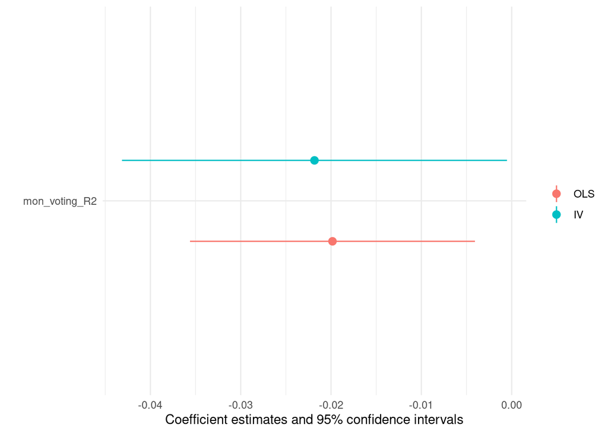

```r
# Plotting the Coefficients
modelplot(m_list, conf_level = 0.95, coef_omit = "Intercept")
```

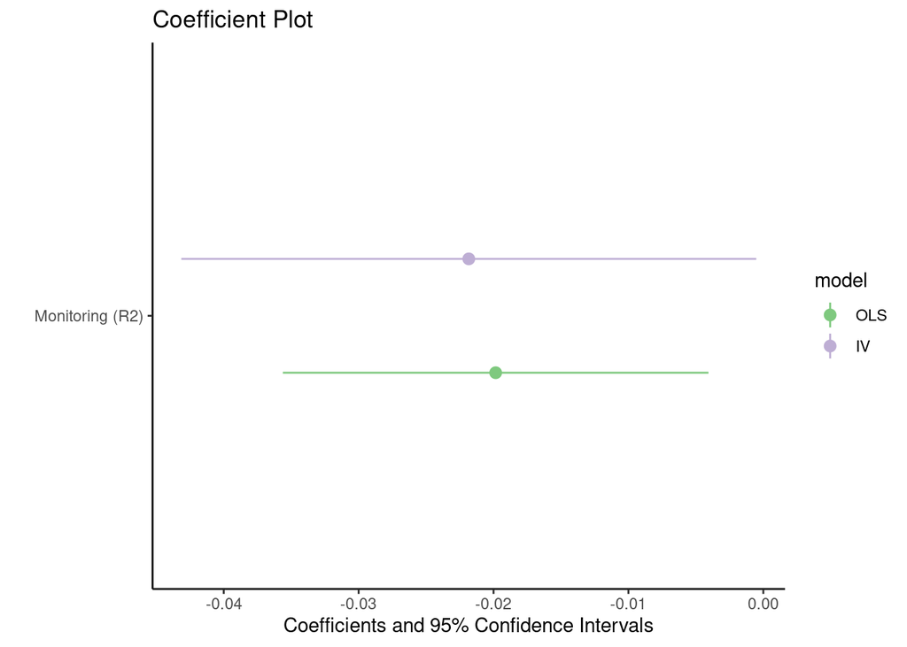

```r
# You can also customise the plot using the ggplot syntax:
modelplot(m_list, conf_level = 0.95, coef_omit = "Intercept", coef_rename = c("mon_voting_R2"="Monitoring (R2)")) +
  scale_color_brewer(type = 'qual') +
  ggtitle("Coefficient Plot") +
  xlab("Coefficients and 95% Confidence Intervals") +
  theme_classic()
```